# PRESENTACIÓN

## Column {data-width=500}

### CANTIDAD DE CLUSTERS (AGNES)

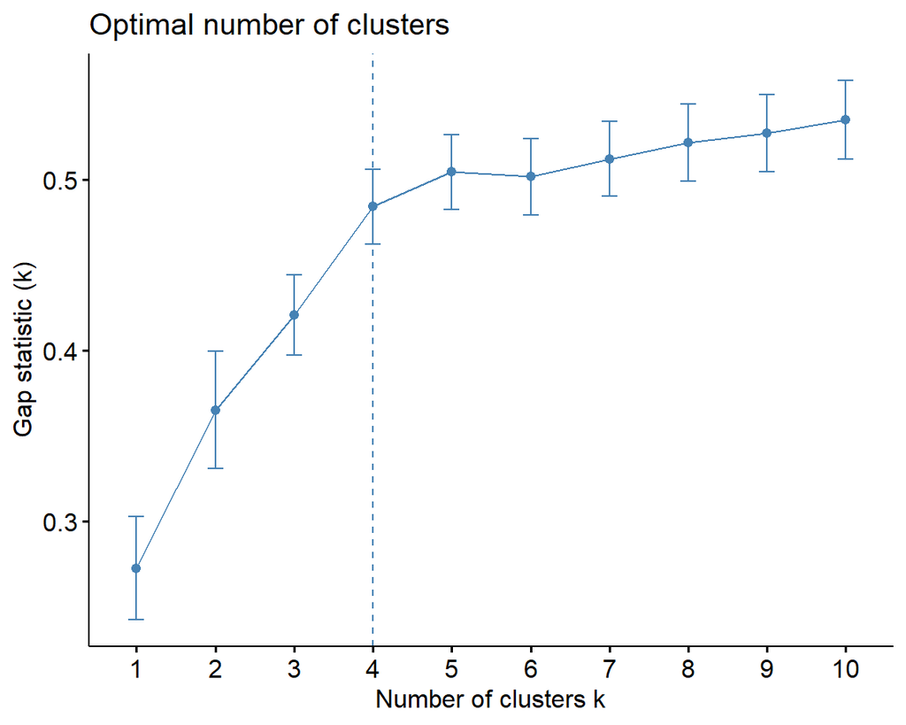

### DENDOGRAMA

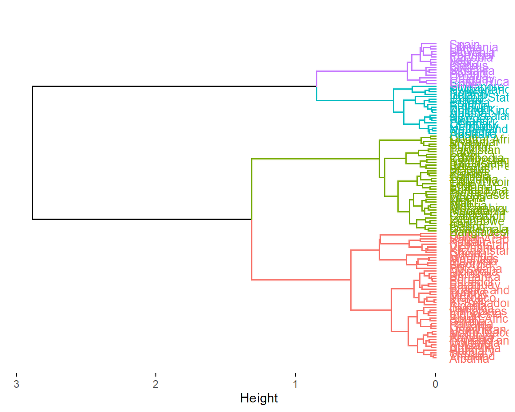

### EVALUACION AGNES

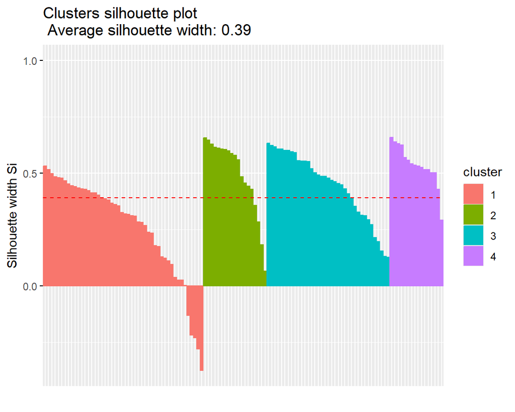

> COMENTARIO: Esta NO es la mejor opción(0.39) este gráfico se evalúa la calidad del agrupamiento en cuatro clusters. Las barras más altas indican mejor cohesión y separación en el agrupamiento. Podemos observar que la mayoría de los elementos están correctamente asignados a sus clusters. Sin embargo, hay casos particulares en el cluster 1, correspondiente a Malaysia, Mauritius, Qatar, etc (con valores negativos) lo que sugiere que está mal agrupado en comparación con el resto.

### GRÁFICO AGNES

```
[1] "Botswana"             "Malaysia"             "Mauritius"
[4] "Qatar"                "United Arab Emirates"
```

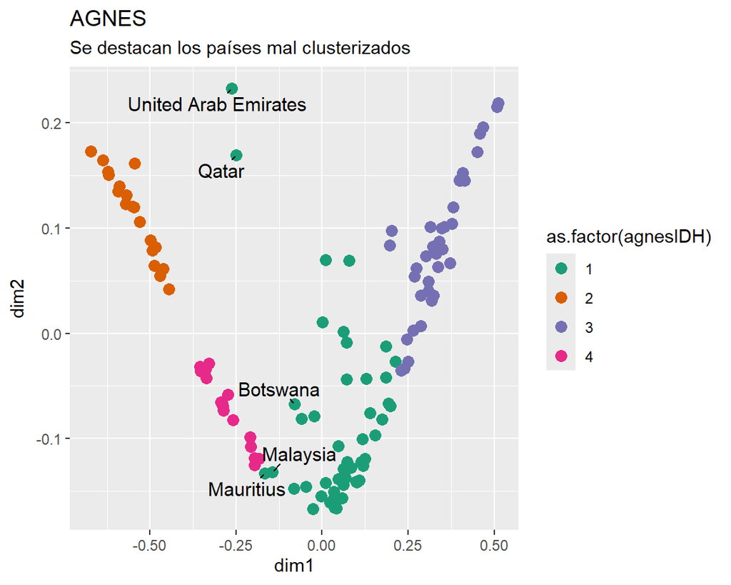

## Column {data-width=500}

### CANTIDAD DE CLUSTERS (DIANA)

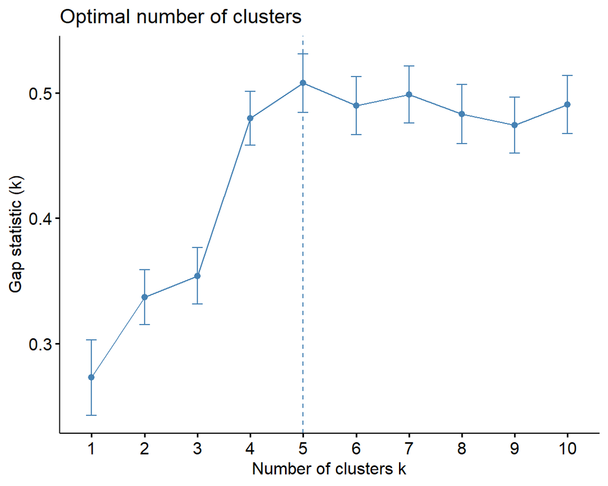

### DENDOGRAMA

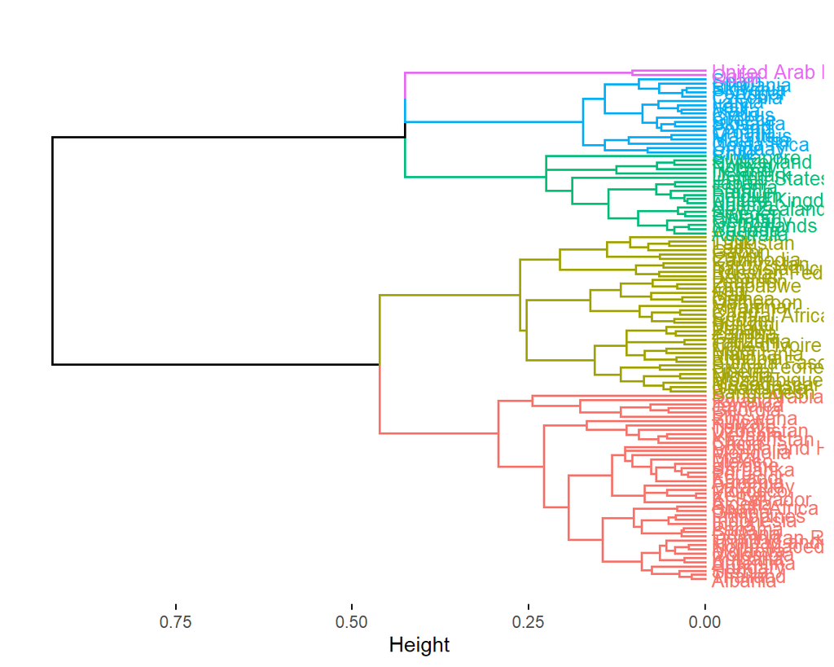

### EVALUACION DIANA

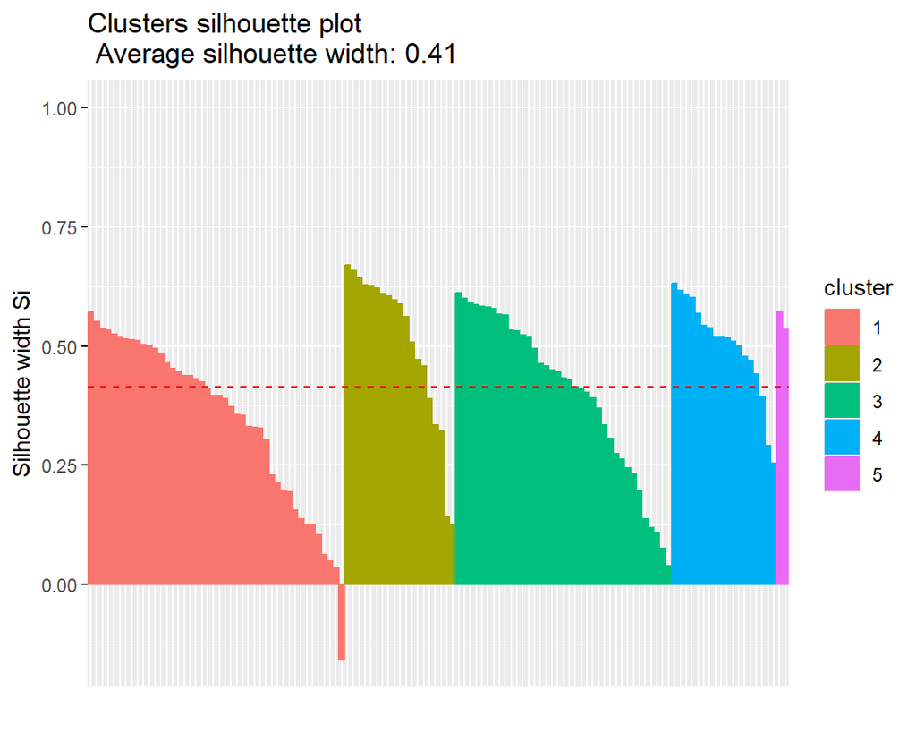

> COMENTARIO: Esta es la mejor opción(0.41) este gráfico se evalúa la calidad del agrupamiento en cinco clusters. Cada barra representa un elemento dentro de un cluster (es decir los países), con los colores diferenciando los grupos. Podemos observar que la mayoría de los elementos están correctamente asignados a sus clusters. Sin embargo, hay un caso particular en el cluster 1 (color rojo), correspondiente a Botswana, con un valor negativo, lo que sugiere que está mal agrupado en comparación con el resto.

### GRAFICO DIANA

```
[1] "Botswana"
```

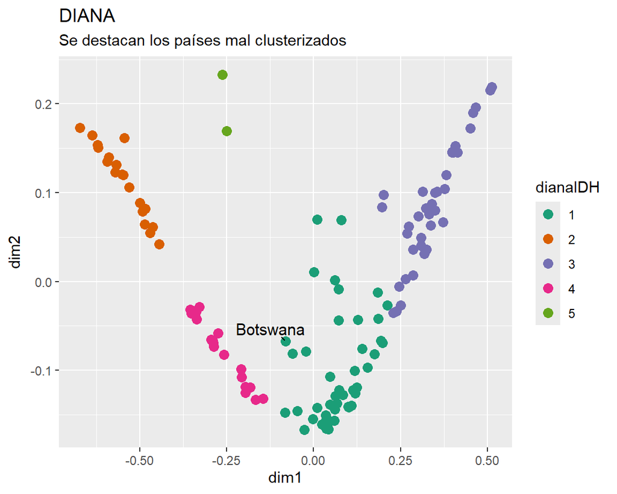